# Project 1: Urban Ministries of Durham

Jesus E. Vazquez

September 24, 2019

### Background & Data Description

Urban Ministries of Durham assist around 6,000 people each year who need food, shelter, clothing and/or supportive services. Some of the programs that they offer is a (1) community shelter where people are given a place to sleep and assistance to help them find a home, a (2) Community Caf? serves three meals a day, seven days a week, 365 days a year, and a (3) food and clothing closet for those that either need food or clothing. Donations, just to as any homeless shelter, are important to maintain services, therefore communicating the importance of donations should be a high priority.

### Approach

**Questions**

1. How is financial support to members of the Urban Ministries of Durham used?
2. What time of the year do members among the community make use of the Community Caf??

**Methods**

To approach these two questions (1) a bar plot with the frequencies of *type of bill paid* will be plotted with the *average amount paid* as a label, and (2) a trend-line on the frequency of meals *food provided* served throughout the *duration of the year* will also be plotted. Having this information handy at the moment of meeting with potential donors is of great importance to communicate how important their help is.

### Results

**How is financial support used?**

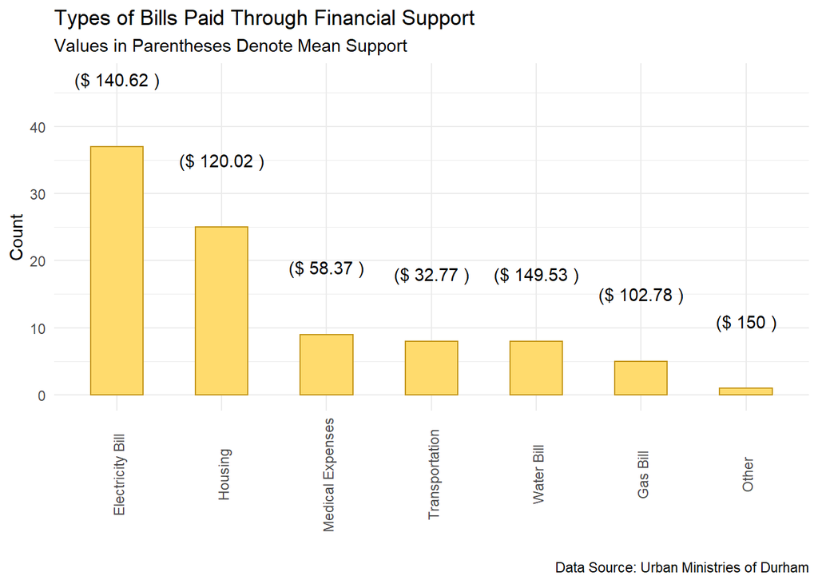

**What time of the year do members among the community make use of the Community Caf??**

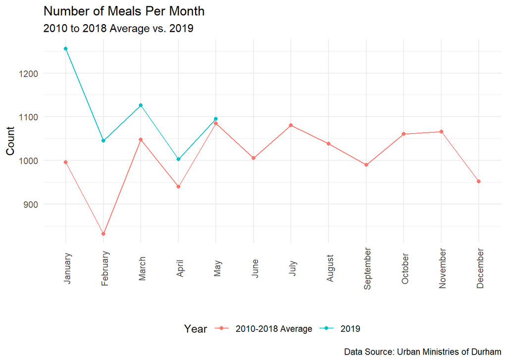

### Conclusions

As the plots suggest, financial assitance helped members of the Urban Ministries of Durham pay for basic neccesities such as electricity and water bills. Given that money used for financial assistance was not misused, the services should come back. 2019 has observed a larger number of meals served per month thus it will also be of interest for the Urban Ministries of Durham to prepapre to serve more meals for the rest of the year.